# 時系列分析 第 5 回 分析例 1

ARMA

Kenichiro Tamaki

2022 年 5 月 9 日

# 1 パッケージ

必要なパッケージは次である.

```r
library(quantmod) # データの取得
library(stargazer) # 記述統計量
library(lmtest) # 時系列モデルにおける p 値
library(forecast) # 予測
```

# 2 関数の作成

自作関数は次である.

**かばん検定**

```r
port <- function(x, lag, fitdf) { # x = 標本, lag = ラグ, fitdf = 自由度の減数
  res <- Box.test(x, lag = lag, type = "Ljung-Box", fitdf = fitdf) # かばん検定
  res <- c(lag, res$statistic, res$parameter, res$p.value) # ラグ, 検定統計量, 自由度, p 値
  names(res) <- c("m", "Q(m)", "df", "p.value") # 名称

  return(res)
}
```

出力例

```r
T <- 500 # 標本数
p <- 1; ar.c <- 0.5 # AR 次数; AR 係数
lag <- 5 # ラグ
fitdf <- 0 # 自由度の減数
# AR(p) の模擬データ
x <- arima.sim(n = T, # 標本数
               list(order = c(p, 0, 0), ar = ar.c)) # AR 次数, AR 係数
port (x, lag, fitdf)
```

```
##       m    Q(m)      df p.value
##   5.000 105.482   5.000   0.000
```

**情報量規準**

```r
ic.arma <- function(x, Lp, Lq) { # x = 標本, Lp = AR 最大次数, Lq = MA 最大次数
  # 結果を代入する変数
  res.aic <- matrix(0, Lp + 1, Lq + 1) # AIC
  res.bic <- matrix(0, Lp + 1, Lq + 1) # BIC
  res.order <- matrix(0, 2, 2) # ARMA 次数

  aic0 <- Inf # AIC の最小値の初期値
  bic0 <- Inf # BIC の最小値の初期値

  T <- length(x) # 標本数

  for (p in 0:Lp) { # p は 0 から Lp まで繰り返す
    for (q in 0:Lq) { # q は 0 から Lq まで繰り返す
      # ARMA(p, q) の推定
      est <- arima(x, # 標本
                   order = c(p, 0, q), # AR 次数, MA 次数
                   method = "ML") # 最尤法

      if (est$code == 0) { # 最適化が収束する場合
        res.aic[p + 1, q + 1] <- AIC(est) / T # ARMA(p, q) の AIC
        res.bic[p + 1, q + 1] <- BIC(est) / T # ARMA(p, q) の BIC

        if (res.aic[p + 1, q + 1] < aic0) { # AIC が最小値より小さい場合
          res.order[1,] <- c(p, q) # AIC を最小にする次数
          aic0 <- res.aic[p + 1, q + 1] # AIC の最小値を更新
        }
        if (res.bic[p + 1, q + 1] < bic0) { # BIC が最小値より小さい場合
          res.order[2,] <- c(p, q) # BIC を最小にする次数
          bic0 <- res.bic[p + 1, q + 1] # BIC の最小値を更新
        }
      } else { # 最適化が収束しない場合
        res.aic[p + 1, q + 1] <- NA # 欠損値
        res.bic[p + 1, q + 1] <- NA # 欠損値
      }
    }
  }

  res.aic <- cbind(0:Lp, res.aic) # AR 次数を追加
  colnames(res.aic) <- c("p ＼ q", 0:Lq) # AIC の列名
  res.bic <- cbind(0:Lp, res.bic) # AR 次数を追加
  colnames(res.bic) <- c("p ＼ q", 0:Lq) # BIC の列名
  rownames(res.order) <- c("AIC", "BIC") # ARMA 次数の行名
  colnames(res.order) <- c("AR", "MA") # ARMA 次数の列名

  return(list(AIC = res.aic, BIC = res.bic, order = res.order))
}
```

出力例

```r
Lp <- Lq <- p + 3 # AR 最大次数, MA 最大次数
ic.arma(x, Lp, Lq)
```

```
## $AIC
##      p ＼ q        0        1        2        3        4
## [1,]      0 3.075132 2.915697 2.896873 2.899158 2.902585
## [2,]      1 2.890346 2.894285 2.898285 2.901028 2.905006
## [3,]      2 2.894285       NA       NA 2.905015       NA
## [4,]      3 2.898284       NA       NA       NA       NA
## [5,]      4 2.901375 2.904640       NA       NA       NA
##
## $BIC
##      p ＼ q        0        1        2        3        4
## [1,]      0 3.091990 2.940985 2.930590 2.941304 2.953160
## [2,]      1 2.915634 2.928002 2.940431 2.951604 2.964011
## [3,]      2 2.928002       NA       NA 2.964020       NA
## [4,]      3 2.940430       NA       NA       NA       NA
## [5,]      4 2.951951 2.963645       NA       NA       NA
##
## $order
##     AR MA
## AIC  1  0
## BIC  1  0
```

# 3 データの概要

産業総合指数を用いて分析例を示す.

## 3.1 データの入手と編集

FRED (Federal Reserve Economic Data) から 産業総合指数 (Production of Total Industry in Japan) を入手する.

- https://fred.stlouisfed.org/series/JPNPROINDMISMEI
- 1960 年 1 月 ～ 2022 年 2 月の月次データ
- 基準は 2015 年
- 季節調整済

```r
getSymbols("JPNPROINDMISMEI", src = 'FRED') # データを取得し JPNPROINDMISMEI に代入
```

```
## [1] "JPNPROINDMISMEI"
```

```r
PTI0 <- to.monthly(JPNPROINDMISMEI, OHLC = F) # 日付を月に変更
head(PTI0, 5) # 最初の 5 個を表示
```

```
##        JPNPROINDMISMEI
## 1 1960        12.11457
## 2 1960        12.70347
## 3 1960        12.70347
## 4 1960        12.95586
## 5 1960        13.03999
```

```r
tail(PTI0, 5) # 最後の 5 個を表示
```

```
##         JPNPROINDMISMEI
## 10 2021        91.39238
## 11 2021        97.19190
## 12 2021        96.39197
## 1 2022         95.69203
## 2 2022         96.09199
```

産業総合指数の時系列をプロットする.

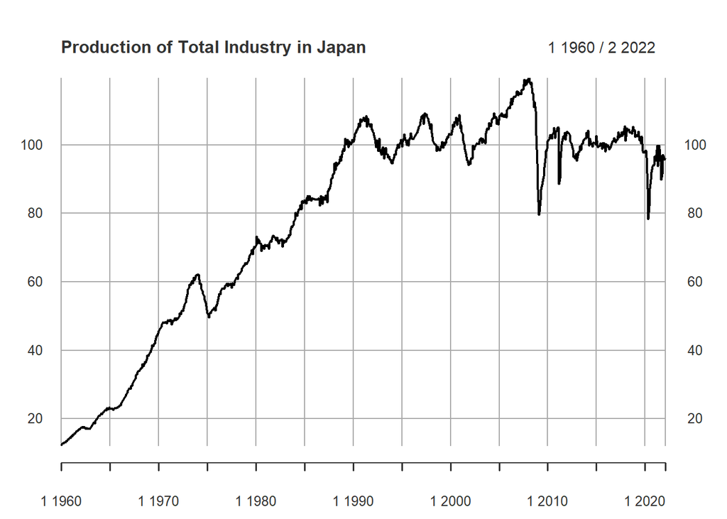

```r
# 時系列プロット
plot(PTI0, # 標本
     main = "Production of Total Industry in Japan") # 図題
```

1990 年以降にデータの性質が変化したと考え, ここでは 1990 年以降を用いる.

- 1990 年 1 月 ～ 2020 年 12 月の観測値を用いてモデルを構築
- 2021 年 1 月 ～ 2021 年 12 月を予測し, 観測値と比較

```r
PTI0 <- PTI0['1990-01::2021-12'] # 1990 年 1 月 ～ 2021 年 12 月
PTI <- PTI0['::2020-12'] # 2020 年 12 月以前
pti0 <- ts(PTI0, frequency = 12, start = c(1990, 1)) # 予測プロットの為に形式を変更
pti <- ts(PTI, frequency = 12, start = c(1990, 1)) # 予測プロットの為に形式を変更
```

## 3.2 時系列プロット

観測値として用いる産業総合指数の時系列をプロットする.

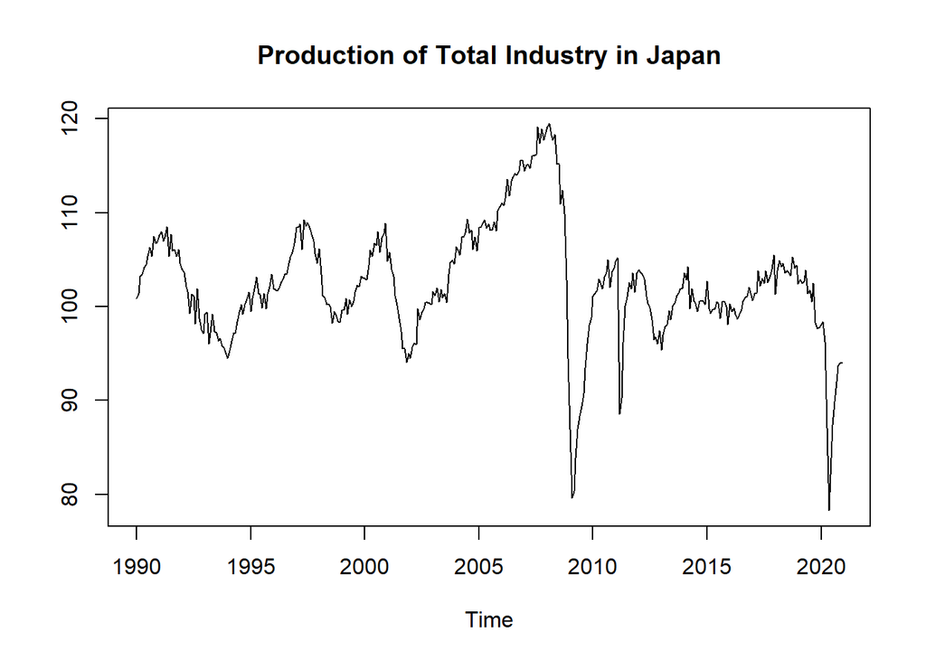

```r
# 時系列プロット
plot(pti, # 標本
     main = "Production of Total Industry in Japan", # 図題
     ylab = "") # y 軸のラベル
```

## 3.3 記述統計量

記述統計量は次である.

```r
stargazer(pti, # 標本
          type = "text", # 出力形式
          summary = TRUE) # 記述統計量
```

```
##
## ===================================================
## Statistic        N   Mean   St. Dev.  Min     Max
## ---------------------------------------------------
## JPNPROINDMISMEI 372 102.532  6.261   78.293 119.473
## ---------------------------------------------------
```

# 4 モデル

## 4.1 自己相関

まず, 自己相関関数, 偏自己相関関数をプロットする.

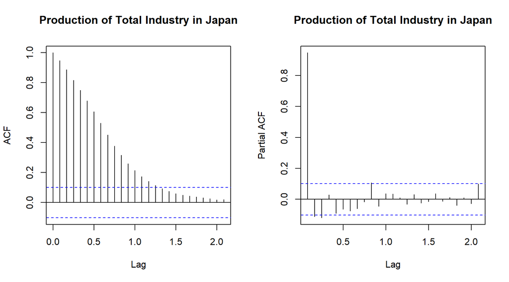

```r
par(mfrow = c(1, 2)) # プロット画面を 1 行 2 列に分割
# 自己相関関数
acf(pti, # 標本
    main = "Production of Total Industry in Japan") # 図題
# 偏自己相関関数
pacf(pti, # 標本
    main = "Production of Total Industry in Japan") # 図題
```

自己相関関数と偏自己相関関数より, 自己相関があると判断できる.

```r
(T <- length(pti)) # 標本数
```

```
## [1] 372
```

```r
(m <- round(log(T))) # ラグ m の目安
```

```
## [1] 6
```

上記で作成した関数を用いて, ラグ $6$, $12$, $18$ に対するかばん検定の結果の表を作成する.

```r
lag <- m * (1:3) # ラグ m, 2m, 3m
fitdf <- 0 # 自由度の減数
res.port <- sapply(lag, port, x = pti, fitdf = fitdf) # x と fitdf に対して各 lag の port を計算

# 表を作成
knitr::kable(t(res.port), # 転置
             digits = c(0, 2, 0, 4), # 少数点以下の最大表示桁数
             col.names = c("$m$", "$Q(m)$", "自由度", "$p$ 値"), # 列名
             caption = "産業総合指数に対するかばん検定", # 表題
             format.args = list(scientific = FALSE)) # 指数表記をしない
```

産業総合指数に対するかばん検定

| $m$ | $Q(m)$ | 自由度 | $p$ 値 |
| --- | --- | --- | --- |
| 6 | 1411.87 | 6 | 0 |
| 12 | 1733.74 | 12 | 0 |
| 18 | 1765.38 | 18 | 0 |

全てにおいて $p$ 値が $0.01$ より小さいので, 有意水準 $1 \%$ で帰無仮説を棄却できる. つまり, 自己相関があると判断できる.

## 4.2 モデルの決定

自己相関関数 (ACF) と偏自己相関関数 (PACF) より, 時系列モデルを決定する. まず, ACF と PACF は減衰しているので定常過程と判断する (厳密には定常性の検定を行う必要がある). 次に, ACF に切断がないので MA モデルは適切でない. PACF に切断があると考えると AR モデルが妥当であり, 次数は $1$, $2$, $3$ などが候補となる. ここでは, より一般的に ARMA モデルを用いて分析を行う.

# 5 推定

パッケージ forecast の関数 auto.arima により計算可能であるが, ここでは用いない.

## 5.1 次数の決定

上記で作成した関数を用いて, ARMA モデルの次数を決定する.

```r
Lp <- Lq <- 4 # 最大次数
res.ic <- ic.arma(pti, Lp, Lq) # 情報量規準を計算

# AIC の表を作成
knitr::kable(res.ic$AIC, # AIC
             digits = c(0, rep(3, Lq + 1)), # 少数点以下の最大表示桁数
             col.names =  c("$p$ $\\backslash$ $q$", 0:Lq), # 列名
             caption = "産業総合指数に対する ARMA($p, q$) の AIC") # 表題
```

産業総合指数に対する ARMA($p, q$) の AIC

| $p$ $\backslash$ $q$ | 0 | 1 | 2 | 3 | 4 |
| --- | --- | --- | --- | --- | --- |
| 0 | 6.515 | 5.571 | 4.963 | 4.688 | 4.525 |
| 1 | NA | 4.193 | NA | 4.183 | 4.184 |
| 2 | 4.190 | 4.206 | NA | NA | NA |
| 3 | 4.180 | 4.181 | NA | NA | NA |
| 4 | 4.183 | 4.185 | 4.185 | NA | NA |

```r
# BIC の表を作成
knitr::kable(res.ic$BIC, # BIC
             digits = c(0, rep(3, Lq + 1)), # 少数点以下の最大表示桁数
             col.names =  c("$p$ $\\backslash$ $q$", 0:Lq), # 列名
             caption = "産業総合指数に対する ARMA($p, q$) の BIC") # 表題
```

産業総合指数に対する ARMA($p, q$) の BIC

| $p$ $\backslash$ $q$ | 0 | 1 | 2 | 3 | 4 |
| --- | --- | --- | --- | --- | --- |
| 0 | 6.536 | 5.602 | 5.005 | 4.741 | 4.588 |
| 1 | NA | 4.235 | NA | 4.247 | 4.258 |
| 2 | 4.232 | 4.259 | NA | NA | NA |
| 3 | 4.233 | 4.244 | NA | NA | NA |
| 4 | 4.247 | 4.258 | 4.269 | NA | NA |

```r
# ARMA 次数の表を作成
knitr::kable(res.ic$order, # ARMA 次数
             caption = "産業総合指数に対する ARMA($p, q$) の 次数") # 表題
```

産業総合指数に対する ARMA($p, q$) の 次数

|  | AR | MA |
| --- | --- | --- |
| AIC | 3 | 0 |
| BIC | 2 | 0 |

AIC では, ARMA$(3, 0)$, BIC では, ARMA$(2, 0)$ が選択される.

**補足**

情報量基準では値の順序 (大小) のみが重要である. ソフトウェアにより値が大きく異なる場合があるが, 順序や結論は同じである (最適化の方法により少し異なる場合もある). 大きく異なる理由は次の 2 点が考えられる.

- 標本数で割っている
- 定数項を除いている

## 5.2 パラメータの推定

AIC では ARMA$(3, 0)$, BIC では ARMA$(2, 0)$ が選択され, 結果が異なるので両方用いて推定を行う.

**Model 1: ARMA$(2, 0)$**

ARMA$(2, 0)$ の推定結果は次である.

```r
order.bic <- append(res.ic$order[2,], 0, after = 1) # BIC により選択された次数
M1 <- arima(pti, # 標本
            order = order.bic, # 次数
            method = "ML") # 最尤法
M1 # 推定結果
```

```
##
## Call:
## arima(x = pti, order = order.bic, method = "ML")
##
## Coefficients:
##          ar1      ar2  intercept
##       1.0592  -0.1150   102.1695
## s.e.  0.0514   0.0515     1.7345
##
## sigma^2 estimated as 3.758:  log likelihood = -775.28,  aic = 1558.57
```

intercept は定数項 $c$ ではなく平均 $\mu$ である. 結果は省略して表示されている. 詳細はヘルプをご覧下さい.

**Model 2: ARMA$(3, 0)$**

ARMA$(3, 0)$ の推定結果は次である.

```r
order.aic <- append(res.ic$order[1,], 0, after = 1) # AIC により選択された次数
M2 <- arima(pti, # 標本
            order = order.aic, # 次数
            method = "ML") # 最尤法
M2 # 推定結果
```

```
##
## Call:
## arima(x = pti, order = order.aic, method = "ML")
##
## Coefficients:
##          ar1     ar2      ar3  intercept
##       1.0450  0.0151  -0.1228   102.2335
## s.e.  0.0513  0.0747   0.0514     1.5463
##
## sigma^2 estimated as 3.701:  log likelihood = -772.46,  aic = 1554.91
```

係数の有意性について考える. $p$ 値を計算するために, パッケージ lmtest にある関数 coeftest を用いる.

**Model 1: ARMA$(2, 0)$**

ARMA$(2, 0)$ の結果は次である.

```r
coeftest(M1) # 係数の p 値
```

```
##
## z test of coefficients:
##
##             Estimate Std. Error z value Pr(>|z|)
## ar1         1.059156   0.051382 20.6136  < 2e-16 ***
## ar2        -0.115026   0.051504 -2.2333  0.02553 *
## intercept 102.169503   1.734522 58.9036  < 2e-16 ***
## ---
## Signif. codes:  0 '***' 0.001 '**' 0.01 '*' 0.05 '.' 0.1 ' ' 1
```

係数と定数項 (平均) は全て有意水準 $5 \%$ で有意である.

**Model 2: ARMA$(3, 0)$**

ARMA$(3, 0)$ の結果は次である.

```r
coeftest(M2) # 係数の p 値
```

```
##
## z test of coefficients:
##
##             Estimate Std. Error z value Pr(>|z|)
## ar1         1.044985   0.051310 20.3659  < 2e-16 ***
## ar2         0.015087   0.074694  0.2020  0.83993
## ar3        -0.122813   0.051447 -2.3872  0.01698 *
## intercept 102.233497   1.546255 66.1168  < 2e-16 ***
## ---
## Signif. codes:  0 '***' 0.001 '**' 0.01 '*' 0.05 '.' 0.1 ' ' 1
```

係数 (ar1, ar3) と定数項 (平均) は有意水準 $5 \%$ で有意である.

Model 2 において, 有意水準 $5 \%$ で有意でない係数 (ar2) を $0$ として推定する.

```r
M2p <- arima(pti, # 標本
            order = order.aic, # 次数
            fixed = c(NA, 0, NA, NA), # 係数を固定 (NA = 固定しない, 0 = 0 に固定)
            transform.pars = F, # 変換しない (係数を固定するために必要)
            method = "ML") # 最尤法
coeftest(M2p) # 係数の p 値
```

```
##
## z test of coefficients:
##
##             Estimate Std. Error z value  Pr(>|z|)
## ar1         1.052556   0.035024  30.052 < 2.2e-16 ***
## ar3        -0.115232   0.035185  -3.275  0.001057 **
## intercept 102.231164   1.547951  66.043 < 2.2e-16 ***
## ---
## Signif. codes:  0 '***' 0.001 '**' 0.01 '*' 0.05 '.' 0.1 ' ' 1
```

係数と定数項 (平均) は全て有意水準 $1 \%$ で有意である.

## 5.3 モデル診断

残差の自己相関を調べ, モデルが妥当かどうかを診断する. まずは, 残差を取り出す.

```r
r1 <- residuals(M1) # Model 1 の残差
r2 <- residuals(M2) # Model 2 の残差
r2p <- residuals(M2p) # Model 2' の残差
```

原系列と残差の自己相関関数をプロットする.

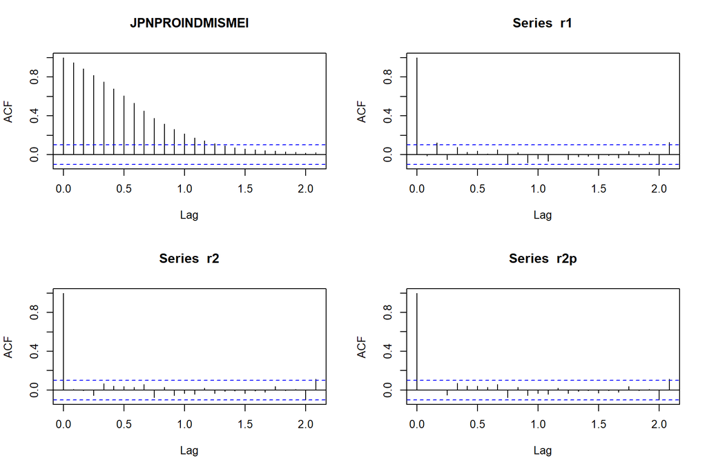

```r
par(mfrow = c(2, 2)) # プロット画面を 2 行 2 列に分割
acf(pti); acf(r1) # 原系列; Model 1 の残差
acf(r2); acf(r2p) # Model 2 の残差; Model 2' の残差
```

原系列と残差の偏自己相関関数をプロットする.

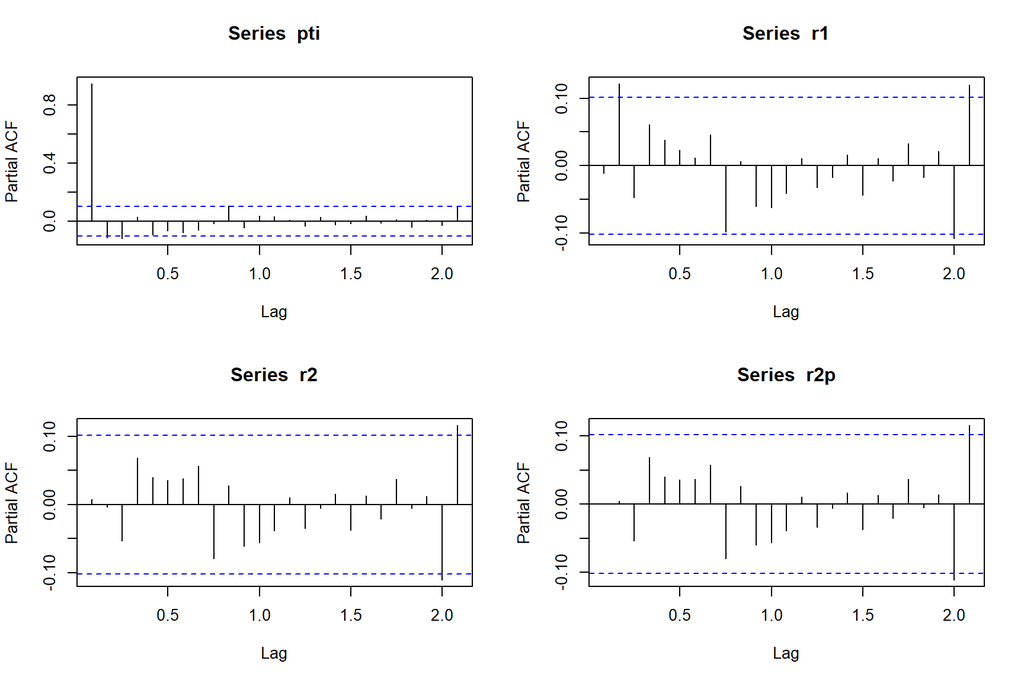

```r
par(mfrow = c(2, 2)) # プロット画面を 2 行 2 列に分割
pacf(pti); pacf(r1) # 原系列; Model 1 の残差
pacf(r2); pacf(r2p) # Model 2 の残差; Model 2' の残差
```

自己相関関数と偏自己相関関数より, Model 1 の残差に自己相関があると想定される.

かばん検定を行う. 残差に対する検定であるから自由度が減少する.

```r
fitdf <- 2 # 自由度の減数
lag <- 1:(2 * m) + fitdf # ラグ (1, ..., 2m) + fitdf
res.port1 <- sapply(lag, port, x = r1, fitdf = fitdf) # x と fitdf に対して各 lag の port を計算

# 表を作成
knitr::kable(t(res.port1), # 転置
             digits = c(0, 2, 0, 4), # 少数点以下の最大表示桁数
             col.names = c("$m$", "$Q(m)$", "自由度", "$p$ 値"), # 列名
             caption = "Model 1 の残差に対するかばん検定", # 表題
             format.args = list(scientific = FALSE)) # 指数表記をしない
```

Model 1 の残差に対するかばん検定

| $m$ | $Q(m)$ | 自由度 | $p$ 値 |
| --- | --- | --- | --- |
| 3 | 6.58 | 1 | 0.0103 |
| 4 | 8.75 | 2 | 0.0126 |
| 5 | 8.99 | 3 | 0.0294 |
| 6 | 9.62 | 4 | 0.0473 |
| 7 | 9.67 | 5 | 0.0850 |
| 8 | 10.76 | 6 | 0.0961 |
| 9 | 14.05 | 7 | 0.0504 |
| 10 | 14.23 | 8 | 0.0759 |
| 11 | 16.78 | 9 | 0.0522 |
| 12 | 17.36 | 10 | 0.0668 |
| 13 | 18.97 | 11 | 0.0617 |
| 14 | 18.98 | 12 | 0.0890 |

自由度 $4$ 以下において $p$ 値が $0.05$ より小さいので, 有意水準 $5 \%$ で帰無仮説を棄却できる. つまり, 残差に自己相関があると判断できるので, Model 1 は適切でない.

```r
fitdf <- 3 # 自由度の減数
lag <- 1:(2 * m) + fitdf # ラグ (1, ..., 2m) + fitdf
res.port2 <- sapply(lag, port, x = r2, fitdf = fitdf) # x と fitdf に対して各 lag の port を計算

# 表を作成
knitr::kable(t(res.port2), # 転置
             digits = c(0, 2, 0, 4), # 少数点以下の最大表示桁数
             col.names = c("$m$", "$Q(m)$", "自由度", "$p$ 値"), # 列名
             caption = "Model 2 の残差に対するかばん検定", # 表題
             format.args = list(scientific = FALSE)) # 指数表記をしない
```

Model 2 の残差に対するかばん検定

| $m$ | $Q(m)$ | 自由度 | $p$ 値 |
| --- | --- | --- | --- |
| 4 | 2.84 | 1 | 0.0919 |
| 5 | 3.47 | 2 | 0.1761 |
| 6 | 4.04 | 3 | 0.2568 |
| 7 | 4.41 | 4 | 0.3539 |
| 8 | 5.63 | 5 | 0.3439 |
| 9 | 7.87 | 6 | 0.2476 |
| 10 | 8.19 | 7 | 0.3165 |
| 11 | 9.43 | 8 | 0.3075 |
| 12 | 9.91 | 9 | 0.3575 |
| 13 | 10.66 | 10 | 0.3849 |
| 14 | 10.79 | 11 | 0.4610 |
| 15 | 11.26 | 12 | 0.5065 |

```r
fitdf <- 2 # 自由度の減数
lag <- 1:(2 * m) + fitdf # ラグ (1, ..., 2m) + fitdf
res.port2p <- sapply(lag, port, x = r2p, fitdf = fitdf) # x と fitdf に対して各 lag の port を計算

# 表を作成
knitr::kable(t(res.port2p), # 転置
             digits = c(0, 2, 0, 4), # 少数点以下の最大表示桁数
             col.names = c("$m$", "$Q(m)$", "自由度", "$p$ 値"), # 列名
             caption = "Model 2' の残差に対するかばん検定", # 表題
             format.args = list(scientific = FALSE)) # 指数表記をしない
```

Model 2’ の残差に対するかばん検定

| $m$ | $Q(m)$ | 自由度 | $p$ 値 |
| --- | --- | --- | --- |
| 3 | 1.10 | 1 | 0.2944 |
| 4 | 2.90 | 2 | 0.2346 |
| 5 | 3.50 | 3 | 0.3207 |
| 6 | 4.08 | 4 | 0.3948 |
| 7 | 4.42 | 5 | 0.4909 |
| 8 | 5.68 | 6 | 0.4602 |
| 9 | 7.98 | 7 | 0.3348 |
| 10 | 8.31 | 8 | 0.4034 |
| 11 | 9.60 | 9 | 0.3842 |
| 12 | 10.05 | 10 | 0.4358 |
| 13 | 10.82 | 11 | 0.4586 |
| 14 | 10.96 | 12 | 0.5327 |

Model 2 と 2’ では, 全ての自由度において $p$ 値が $0.05$ より大きいので, 有意水準 $5 \%$ で帰無仮説を棄却できない. つまり, 残差に自己相関があると判断できないので, Model 2 と 2’ は妥当である.

上記より, 原系列を $y_{t}$ とすると, 推定されたモデルは次である.

**Model 1: ARMA$(2, 0)$ (参考)**

$$\begin{align}
& x_{t} = y_{t} - 102 \\
& x_{t} = 1.06 x_{t - 1} -0.115 x_{t - 2} + \varepsilon_{t}, \quad
\sigma^{2} = 3.76
\end{align}$$

**Model 2: ARMA$(3, 0)$**

$$\begin{align}
& x_{t} = y_{t} - 102 \\
& x_{t} = 1.04 x_{t - 1} + 0.0151 x_{t - 2} -0.123 x_{t - 3} +
\varepsilon_{t}, \quad \sigma^{2} = 3.7
\end{align}$$

**Model 2’: ARMA$(3, 0)$**

$$\begin{align}
& x_{t} = y_{t} - 102 \\
& x_{t} = 1.05 x_{t - 1} -0.115 x_{t - 3} + \varepsilon_{t}, \quad
\sigma^{2} = 3.7
\end{align}$$

# 6 予測

パッケージ forecast を用いて予測を行う. モデル診断の結果より, Model 2 と 2’ は妥当である. 比較の為, Model 1 も含めて $12$ 期先予測を行う.

```r
n.ahead <- 12 # 期先
f1 <- forecast(M1, h = n.ahead) # Model 1 を用いた予測
f2 <- forecast(M2, h = n.ahead) # Model 2 を用いた予測
f2p <- forecast(M2p, h = n.ahead) # Model 2' を用いた予測
```

予測値と観測値を重ねてプロットする. 図を重ねる場合は, $y$ 軸の範囲を合わせる必要がある.

```r
range(pti) # 値域
```

```
## [1]  78.29348 119.47322
```

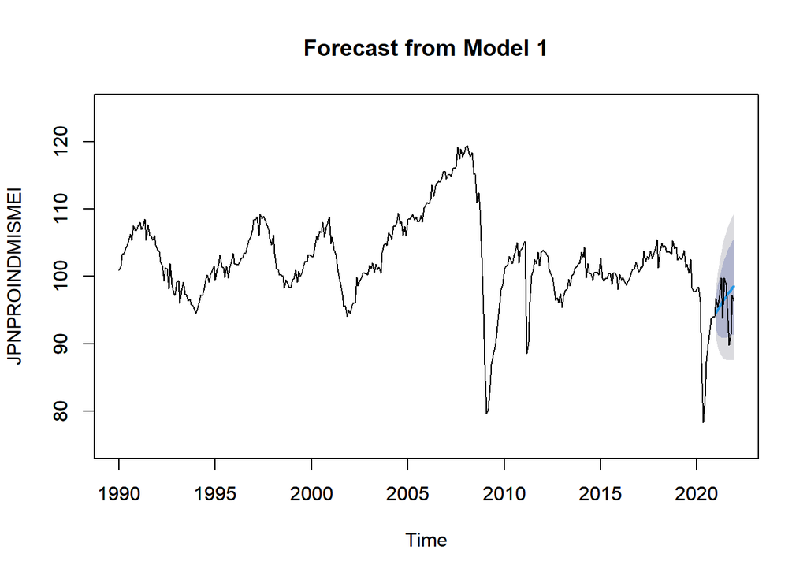

```r
ylim <- c(75, 125) # y 軸の範囲
plot(f1, # 予測値
     ylim = ylim, # y 軸の範囲
     main = "Forecast from Model 1") # 図題
par(new = T) # プロットを重ねる
plot(pti0, # 観測値
     ylim = ylim) # y 軸の範囲
```

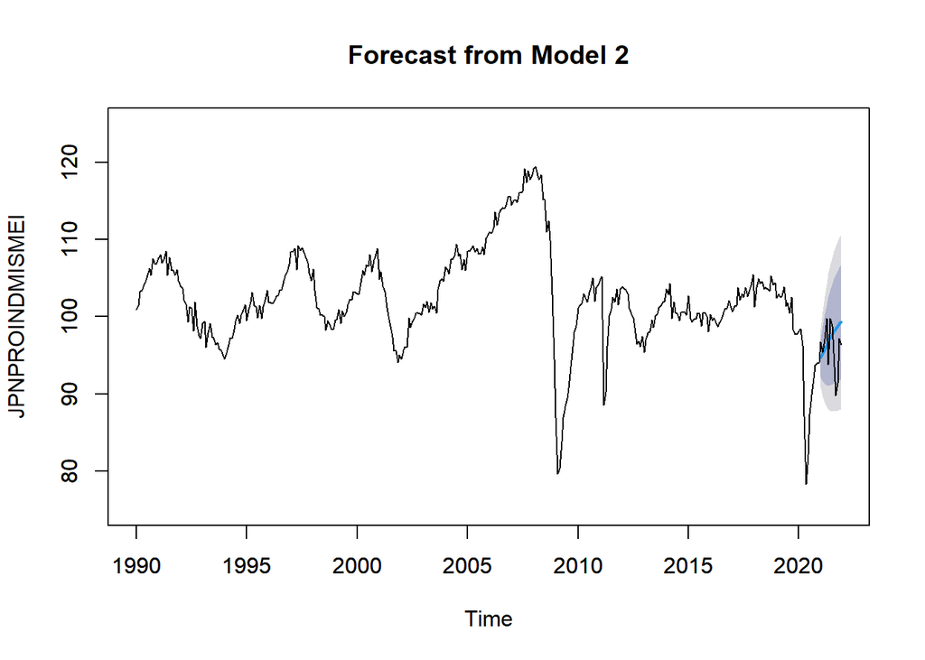

```r
plot(f2, # 予測値
     ylim = ylim, # y 軸の範囲
     main = "Forecast from Model 2") # 図題
par(new = T) # プロットを重ねる
plot(pti0, # 観測値
     ylim = ylim) # y 軸の範囲
```

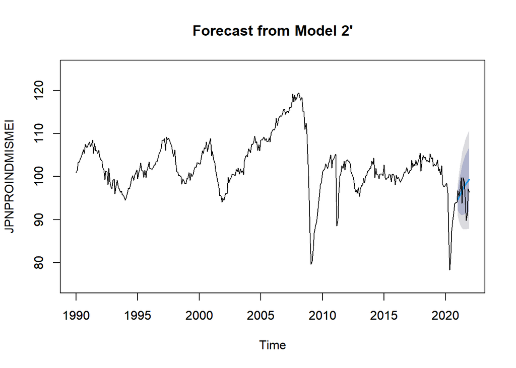

```r
plot(f2p, # 予測値
     ylim = ylim, # y 軸の範囲
     main = "Forecast from Model 2'") # 図題
par(new = T) # プロットを重ねる
plot(pti0, # 観測値
     ylim = ylim) # y 軸の範囲
```

予測値と観測値の差の 2 乗の平均は次である.

```r
pti1 <- window(pti0, c(2021, 1), c(2021, 12)) # 予測部分の観測値
mean((f1$mean - pti1)^2) # Model 1
```

```
## [1] 13.01249
```

```r
mean((f2$mean - pti1)^2) # Model 2
```

```
## [1] 15.27339
```

```r
mean((f2p$mean - pti1)^2) # Model 2'
```

```
## [1] 15.25634
```

予測値と観測値の差の 2 乗の平均を基準とすると, モデル診断において適切でないと判断された Model 1 が最小となるが, この結果に信頼性はない. この規準では Model 2’ が最も適切である.

予測の信頼区間の幅は次である.

```r
f2.w <- (f2$upper - f2$lower)[,2] # Model 2 の 95% 信頼区間の幅
f2p.w <- (f2p$upper - f2p$lower)[,2] # Model 2' の 95% 信頼区間の幅
f2.w / f2p.w # 信頼区間の幅の比率
```

```
##            Jan       Feb       Mar       Apr       May       Jun       Jul
## 2021 0.9999447 0.9961709 0.9972974 0.9977120 0.9982255 0.9985598 0.9988089
##            Aug       Sep       Oct       Nov       Dec
## 2021 0.9989795 0.9990985 0.9991799 0.9992351 0.9992717
```

全て $1$ より小さいので, 信頼区間の幅は Model 2 の方が小さい. 一般的に, 信頼区間の幅が最も小さい予測が最適であるから, AIC により次数を決定し, 係数の有意性を考慮しない Model 2 が最適となる.